# temp-163586397696161653

```python
import pandas as pd
import numpy as np
df = pd.read_csv('C:/Users/Bhargaw/Downloads/loans_full_schema.csv')
```

```python
df
```

|  | emp_title | emp_length | state | homeownership | annual_income | verified_income | debt_to_income | annual_income_joint | verification_income_joint | debt_to_income_joint | ... | sub_grade | issue_month | loan_status | initial_listing_status | disbursement_method | balance | paid_total | paid_principal | paid_interest | paid_late_fees |
| --- | --- | --- | --- | --- | --- | --- | --- | --- | --- | --- | --- | --- | --- | --- | --- | --- | --- | --- | --- | --- | --- |
| 0 | global config engineer | 3.0 | NJ | MORTGAGE | 90000.0 | Verified | 18.01 | NaN | NaN | NaN | ... | C3 | Mar-2018 | Current | whole | Cash | 27015.86 | 1999.330000 | 984.14 | 1015.19 | 0.0 |
| 1 | warehouse office clerk | 10.0 | HI | RENT | 40000.0 | Not Verified | 5.04 | NaN | NaN | NaN | ... | C1 | Feb-2018 | Current | whole | Cash | 4651.37 | 499.120000 | 348.63 | 150.49 | 0.0 |
| 2 | assembly | 3.0 | WI | RENT | 40000.0 | Source Verified | 21.15 | NaN | NaN | NaN | ... | D1 | Feb-2018 | Current | fractional | Cash | 1824.63 | 281.800000 | 175.37 | 106.43 | 0.0 |
| 3 | customer service | 1.0 | PA | RENT | 30000.0 | Not Verified | 10.16 | NaN | NaN | NaN | ... | A3 | Jan-2018 | Current | whole | Cash | 18853.26 | 3312.890000 | 2746.74 | 566.15 | 0.0 |
| 4 | security supervisor | 10.0 | CA | RENT | 35000.0 | Verified | 57.96 | 57000.0 | Verified | 37.66 | ... | C3 | Mar-2018 | Current | whole | Cash | 21430.15 | 2324.650000 | 1569.85 | 754.80 | 0.0 |
| 5 | NaN | NaN | KY | OWN | 34000.0 | Not Verified | 6.46 | NaN | NaN | NaN | ... | A3 | Jan-2018 | Current | whole | Cash | 4256.71 | 873.130000 | 743.29 | 129.84 | 0.0 |
| 6 | hr | 10.0 | MI | MORTGAGE | 35000.0 | Source Verified | 23.66 | 155000.0 | Not Verified | 13.12 | ... | C2 | Jan-2018 | Current | whole | Cash | 22560.00 | 2730.510000 | 1440.00 | 1290.51 | 0.0 |
| 7 | police | 10.0 | AZ | MORTGAGE | 110000.0 | Source Verified | 16.19 | NaN | NaN | NaN | ... | B5 | Jan-2018 | Current | whole | Cash | 19005.39 | 1765.840000 | 994.61 | 771.23 | 0.0 |
| 8 | parts | 10.0 | NV | MORTGAGE | 65000.0 | Source Verified | 36.48 | NaN | NaN | NaN | ... | C2 | Feb-2018 | Current | whole | Cash | 18156.66 | 2703.220000 | 1843.34 | 859.88 | 0.0 |
| 9 | 4th person | 3.0 | IL | RENT | 30000.0 | Not Verified | 18.91 | NaN | NaN | NaN | ... | A3 | Mar-2018 | Current | fractional | Cash | 6077.13 | 391.150000 | 322.87 | 68.28 | 0.0 |
| 10 | supervisor | 10.0 | IL | MORTGAGE | 75000.0 | Verified | 10.45 | NaN | NaN | NaN | ... | C4 | Mar-2018 | Current | whole | Cash | 24143.51 | 1764.950000 | 856.49 | 908.46 | 0.0 |
| 11 | register nurse | 2.0 | FL | MORTGAGE | 91900.0 | Source Verified | 1.82 | NaN | NaN | NaN | ... | B2 | Mar-2018 | Current | whole | Cash | 38434.20 | 2500.840000 | 1565.80 | 935.04 | 0.0 |
| 12 | respiratory therapist & sleep lab tech | 5.0 | SC | MORTGAGE | 122000.0 | Source Verified | 12.06 | NaN | NaN | NaN | ... | C2 | Feb-2018 | Current | whole | Cash | 14525.30 | 2204.880000 | 1474.70 | 730.18 | 0.0 |
| 13 | senior inspector | 10.0 | CO | MORTGAGE | 88000.0 | Source Verified | 3.67 | NaN | NaN | NaN | ... | B1 | Feb-2018 | Current | whole | DirectPay | 16326.13 | 1060.470000 | 673.87 | 386.60 | 0.0 |
| 14 | NaN | NaN | FL | MORTGAGE | 17000.0 | Verified | 33.98 | NaN | NaN | NaN | ... | D3 | Jan-2018 | Current | whole | Cash | 2744.21 | 454.360000 | 255.79 | 198.57 | 0.0 |
| 15 | dental hygienist | 10.0 | TN | MORTGAGE | 60000.0 | Not Verified | 38.46 | NaN | NaN | NaN | ... | D3 | Feb-2018 | Current | whole | Cash | 19172.64 | 2023.740000 | 827.36 | 1196.38 | 0.0 |
| 16 | NaN | NaN | NV | MORTGAGE | 60000.0 | Not Verified | 31.22 | NaN | NaN | NaN | ... | D3 | Jan-2018 | Current | whole | Cash | 11374.52 | 1532.080000 | 625.48 | 906.60 | 0.0 |
| 17 | onsite medical | 3.0 | NV | RENT | 72000.0 | Source Verified | 20.33 | NaN | NaN | NaN | ... | F1 | Jan-2018 | Current | whole | Cash | 28798.08 | 4687.880000 | 1201.92 | 3485.96 | 0.0 |
| 18 | operational risk manager | 10.0 | IL | MORTGAGE | 210000.0 | Verified | 9.53 | NaN | NaN | NaN | ... | E5 | Feb-2018 | Fully Paid | fractional | Cash | 0.00 | 5202.642672 | 5000.00 | 202.64 | 0.0 |
| 19 | welder | 1.0 | CA | MORTGAGE | 83000.0 | Source Verified | 18.44 | NaN | NaN | NaN | ... | C4 | Jan-2018 | Fully Paid | whole | Cash | 0.00 | 20653.717722 | 20000.00 | 653.72 | 0.0 |
| 20 | maintenance adm assistant | 10.0 | KY | MORTGAGE | 50000.0 | Not Verified | 15.60 | NaN | NaN | NaN | ... | A2 | Jan-2018 | Current | fractional | Cash | 6102.23 | 1063.690000 | 897.77 | 165.92 | 0.0 |
| 21 | warranty administrator | 1.0 | NV | MORTGAGE | 42000.0 | Source Verified | 32.00 | 95000.0 | Source Verified | 16.12 | ... | B5 | Mar-2018 | Current | whole | Cash | 9296.37 | 989.490000 | 703.63 | 285.86 | 0.0 |
| 22 | underwriter | 5.0 | NJ | MORTGAGE | 100000.0 | Not Verified | 26.53 | NaN | NaN | NaN | ... | C2 | Feb-2018 | Current | whole | Cash | 20045.30 | 1909.570000 | 1004.70 | 904.87 | 0.0 |
| 23 | NaN | NaN | TX | MORTGAGE | 40280.0 | Verified | 7.27 | NaN | NaN | NaN | ... | A3 | Mar-2018 | Current | whole | Cash | 3323.42 | 223.710000 | 176.58 | 47.13 | 0.0 |
| 24 | program analyst | 10.0 | VA | RENT | 82000.0 | Not Verified | 17.31 | NaN | NaN | NaN | ... | A5 | Mar-2018 | Current | fractional | Cash | 7403.61 | 744.570000 | 596.39 | 148.18 | 0.0 |
| 25 | surveyor/cadd tech | 7.0 | PA | MORTGAGE | 55000.0 | Source Verified | 14.42 | NaN | NaN | NaN | ... | C1 | Feb-2018 | Current | whole | Cash | 17342.65 | 1205.330000 | 657.35 | 547.98 | 0.0 |
| 26 | associated | 1.0 | NY | RENT | 55000.0 | Source Verified | 13.68 | NaN | NaN | NaN | ... | B5 | Mar-2018 | Current | whole | Cash | 9432.28 | 750.790000 | 567.72 | 183.07 | 0.0 |
| 27 | inventory control specialist | 5.0 | IL | RENT | 33000.0 | Not Verified | 19.38 | NaN | NaN | NaN | ... | A4 | Feb-2018 | Current | whole | Cash | 2557.44 | 696.630000 | 642.56 | 54.07 | 0.0 |
| 28 | inventory control | 3.0 | GA | RENT | 60000.0 | Not Verified | 11.00 | NaN | NaN | NaN | ... | A1 | Jan-2018 | Current | whole | Cash | 8704.48 | 1498.360000 | 1295.52 | 202.84 | 0.0 |
| 29 | sr direct supoort professional | 4.0 | MO | MORTGAGE | 48000.0 | Source Verified | 2.88 | NaN | NaN | NaN | ... | A2 | Mar-2018 | Current | whole | Cash | 5540.54 | 544.140000 | 459.46 | 84.68 | 0.0 |
| ... | ... | ... | ... | ... | ... | ... | ... | ... | ... | ... | ... | ... | ... | ... | ... | ... | ... | ... | ... | ... | ... |
| 9970 | assistant clinical director | 0.0 | NY | RENT | 87000.0 | Source Verified | 17.30 | NaN | NaN | NaN | ... | C1 | Feb-2018 | Current | whole | Cash | 18069.98 | 1700.810000 | 930.02 | 770.79 | 0.0 |
| 9971 | owner | 5.0 | CA | RENT | 50000.0 | Not Verified | 2.39 | NaN | NaN | NaN | ... | A5 | Mar-2018 | Fully Paid | whole | Cash | 0.00 | 8024.760000 | 8000.00 | 24.76 | 0.0 |
| 9972 | bookkeeper | 3.0 | CA | RENT | 33480.0 | Not Verified | 23.98 | NaN | NaN | NaN | ... | C4 | Feb-2018 | Current | whole | Cash | 8164.76 | 1237.900000 | 810.24 | 427.66 | 0.0 |
| 9973 | regional controller | 6.0 | FL | RENT | 97000.0 | Verified | 38.52 | NaN | NaN | NaN | ... | D2 | Mar-2018 | Current | whole | Cash | 19374.64 | 1517.840000 | 625.36 | 892.48 | 0.0 |
| 9974 | tire technician | 10.0 | FL | MORTGAGE | 25000.0 | Not Verified | 46.86 | 70598.0 | Not Verified | 23.95 | ... | C5 | Jan-2018 | Current | fractional | Cash | 6215.74 | 1251.910000 | 784.26 | 467.65 | 0.0 |
| 9975 | NaN | NaN | MD | MORTGAGE | 95000.0 | Source Verified | 10.66 | NaN | NaN | NaN | ... | C3 | Mar-2018 | Current | whole | Cash | 18634.90 | 2037.090000 | 1365.10 | 671.99 | 0.0 |
| 9976 | NaN | NaN | MI | MORTGAGE | 90000.0 | Not Verified | 24.36 | NaN | NaN | NaN | ... | B1 | Mar-2018 | Current | whole | Cash | 13321.35 | 932.700000 | 678.65 | 254.05 | 0.0 |
| 9977 | director | 10.0 | AZ | MORTGAGE | 125000.0 | Source Verified | 21.33 | NaN | NaN | NaN | ... | D1 | Jan-2018 | Current | whole | Cash | 23629.06 | 3053.310000 | 1370.94 | 1682.37 | 0.0 |
| 9978 | provider enrollment | 4.0 | MA | RENT | 32000.0 | Verified | 37.06 | NaN | NaN | NaN | ... | D2 | Mar-2018 | Current | whole | Cash | 6552.11 | 756.770000 | 447.89 | 308.88 | 0.0 |
| 9979 | sales manager | 7.0 | OH | MORTGAGE | 170000.0 | Verified | 10.40 | NaN | NaN | NaN | ... | A2 | Feb-2018 | Current | fractional | Cash | 26929.76 | 3644.870000 | 3070.24 | 574.63 | 0.0 |
| 9980 | truck driver | 2.0 | MA | RENT | 85000.0 | Source Verified | 12.40 | NaN | NaN | NaN | ... | B1 | Mar-2018 | Current | whole | Cash | 13905.04 | 1432.170000 | 1094.96 | 337.21 | 0.0 |
| 9981 | project manager | 7.0 | KY | MORTGAGE | 64000.0 | Not Verified | 36.49 | 194000.0 | Not Verified | 23.72 | ... | B2 | Jan-2018 | In Grace Period | whole | Cash | 27089.00 | 3892.940000 | 2911.00 | 981.94 | 0.0 |
| 9982 | director of finance | 0.0 | CA | MORTGAGE | 100000.0 | Not Verified | 21.71 | NaN | NaN | NaN | ... | B2 | Jan-2018 | Current | whole | Cash | 15161.63 | 1348.810000 | 838.37 | 510.44 | 0.0 |
| 9983 | nurse practitioner | 3.0 | OH | MORTGAGE | 114000.0 | Not Verified | 14.60 | NaN | NaN | NaN | ... | B2 | Jan-2018 | Current | whole | Cash | 17564.07 | 3212.420000 | 2435.93 | 776.49 | 0.0 |
| 9984 | sous chef | 7.0 | CT | MORTGAGE | 49000.0 | Source Verified | 36.20 | 99000.0 | Source Verified | 28.29 | ... | D5 | Jan-2018 | In Grace Period | whole | Cash | 29990.90 | 3333.600000 | 1209.10 | 2124.50 | 0.0 |
| 9985 | manager, store operations | 6.0 | OH | MORTGAGE | 106000.0 | Not Verified | 22.26 | NaN | NaN | NaN | ... | A4 | Jan-2018 | Current | whole | Cash | 10923.77 | 1934.750000 | 1576.23 | 358.52 | 0.0 |
| 9986 | operations | 0.0 | NH | MORTGAGE | 150000.0 | Source Verified | 6.26 | NaN | NaN | NaN | ... | A2 | Mar-2018 | Current | fractional | Cash | 37963.23 | 2409.320000 | 2036.77 | 372.55 | 0.0 |
| 9987 | credit analyst | 6.0 | TX | MORTGAGE | 55000.0 | Source Verified | 22.19 | 100000.0 | Not Verified | 30.77 | ... | B1 | Mar-2018 | Current | whole | Cash | 15365.77 | 989.710000 | 634.23 | 355.48 | 0.0 |
| 9988 | mortgage closer | 1.0 | MD | RENT | 65000.0 | Not Verified | 9.77 | NaN | NaN | NaN | ... | B2 | Mar-2018 | Current | whole | Cash | 2968.03 | 307.660000 | 231.97 | 75.69 | 0.0 |
| 9989 | inspector/packer | 10.0 | AZ | RENT | 65000.0 | Verified | 27.10 | NaN | NaN | NaN | ... | C4 | Jan-2018 | Current | fractional | Cash | 9421.91 | 1174.130000 | 578.09 | 596.04 | 0.0 |
| 9990 | medical director | 4.0 | NJ | OWN | 96774.0 | Source Verified | 0.04 | NaN | NaN | NaN | ... | B1 | Feb-2018 | Current | fractional | Cash | 7386.91 | 12975.620000 | 12613.09 | 362.53 | 0.0 |
| 9991 | teacher | 10.0 | MA | MORTGAGE | 75000.0 | Source Verified | 28.45 | 210000.0 | Source Verified | 23.46 | ... | B5 | Jan-2018 | Current | whole | Cash | 32813.38 | 3868.590000 | 2186.62 | 1681.97 | 0.0 |
| 9992 | program director | 5.0 | NY | RENT | 70000.0 | Not Verified | 15.31 | NaN | NaN | NaN | ... | B2 | Jan-2018 | Current | whole | DirectPay | 21487.30 | 2426.810000 | 1512.70 | 914.11 | 0.0 |
| 9993 | service advisor | 0.0 | NC | MORTGAGE | 20000.0 | Source Verified | 23.23 | NaN | NaN | NaN | ... | A5 | Jan-2018 | Current | whole | Cash | 4374.69 | 778.670000 | 625.31 | 153.36 | 0.0 |
| 9994 | da coordinator | 1.0 | WA | RENT | 40000.0 | Not Verified | 12.07 | NaN | NaN | NaN | ... | B3 | Mar-2018 | Current | fractional | Cash | 1854.81 | 3064.650000 | 2945.19 | 119.46 | 0.0 |
| 9995 | owner | 10.0 | TX | RENT | 108000.0 | Source Verified | 22.28 | NaN | NaN | NaN | ... | A4 | Jan-2018 | Current | whole | Cash | 21586.34 | 2969.800000 | 2413.66 | 556.14 | 0.0 |
| 9996 | director | 8.0 | PA | MORTGAGE | 121000.0 | Verified | 32.38 | NaN | NaN | NaN | ... | D3 | Feb-2018 | Current | whole | Cash | 9147.44 | 1456.310000 | 852.56 | 603.75 | 0.0 |
| 9997 | toolmaker | 10.0 | CT | MORTGAGE | 67000.0 | Verified | 45.26 | 107000.0 | Source Verified | 29.57 | ... | E2 | Feb-2018 | Current | fractional | Cash | 27617.65 | 4620.800000 | 2382.35 | 2238.45 | 0.0 |
| 9998 | manager | 1.0 | WI | MORTGAGE | 80000.0 | Source Verified | 11.99 | NaN | NaN | NaN | ... | A1 | Feb-2018 | Current | whole | Cash | 21518.12 | 2873.310000 | 2481.88 | 391.43 | 0.0 |
| 9999 | operations analyst | 3.0 | CT | RENT | 66000.0 | Not Verified | 20.82 | NaN | NaN | NaN | ... | B4 | Feb-2018 | Current | whole | Cash | 11574.83 | 1658.560000 | 1225.17 | 433.39 | 0.0 |

10000 rows × 55 columns

```python
pd1 = df.dropna(axis=1,how= 'any')
```

```python
pd1
```

|  | state | homeownership | annual_income | verified_income | delinq_2y | earliest_credit_line | inquiries_last_12m | total_credit_lines | open_credit_lines | total_credit_limit | ... | sub_grade | issue_month | loan_status | initial_listing_status | disbursement_method | balance | paid_total | paid_principal | paid_interest | paid_late_fees |
| --- | --- | --- | --- | --- | --- | --- | --- | --- | --- | --- | --- | --- | --- | --- | --- | --- | --- | --- | --- | --- | --- |
| 0 | NJ | MORTGAGE | 90000.0 | Verified | 0 | 2001 | 6 | 28 | 10 | 70795 | ... | C3 | Mar-2018 | Current | whole | Cash | 27015.86 | 1999.330000 | 984.14 | 1015.19 | 0.0 |
| 1 | HI | RENT | 40000.0 | Not Verified | 0 | 1996 | 1 | 30 | 14 | 28800 | ... | C1 | Feb-2018 | Current | whole | Cash | 4651.37 | 499.120000 | 348.63 | 150.49 | 0.0 |
| 2 | WI | RENT | 40000.0 | Source Verified | 0 | 2006 | 4 | 31 | 10 | 24193 | ... | D1 | Feb-2018 | Current | fractional | Cash | 1824.63 | 281.800000 | 175.37 | 106.43 | 0.0 |
| 3 | PA | RENT | 30000.0 | Not Verified | 0 | 2007 | 0 | 4 | 4 | 25400 | ... | A3 | Jan-2018 | Current | whole | Cash | 18853.26 | 3312.890000 | 2746.74 | 566.15 | 0.0 |
| 4 | CA | RENT | 35000.0 | Verified | 0 | 2008 | 7 | 22 | 16 | 69839 | ... | C3 | Mar-2018 | Current | whole | Cash | 21430.15 | 2324.650000 | 1569.85 | 754.80 | 0.0 |
| 5 | KY | OWN | 34000.0 | Not Verified | 1 | 1990 | 6 | 32 | 12 | 42100 | ... | A3 | Jan-2018 | Current | whole | Cash | 4256.71 | 873.130000 | 743.29 | 129.84 | 0.0 |
| 6 | MI | MORTGAGE | 35000.0 | Source Verified | 0 | 2004 | 1 | 12 | 10 | 291852 | ... | C2 | Jan-2018 | Current | whole | Cash | 22560.00 | 2730.510000 | 1440.00 | 1290.51 | 0.0 |
| 7 | AZ | MORTGAGE | 110000.0 | Source Verified | 1 | 2005 | 1 | 30 | 15 | 342336 | ... | B5 | Jan-2018 | Current | whole | Cash | 19005.39 | 1765.840000 | 994.61 | 771.23 | 0.0 |
| 8 | NV | MORTGAGE | 65000.0 | Source Verified | 1 | 1998 | 3 | 35 | 21 | 283190 | ... | C2 | Feb-2018 | Current | whole | Cash | 18156.66 | 2703.220000 | 1843.34 | 859.88 | 0.0 |
| 9 | IL | RENT | 30000.0 | Not Verified | 0 | 2001 | 0 | 9 | 6 | 33114 | ... | A3 | Mar-2018 | Current | fractional | Cash | 6077.13 | 391.150000 | 322.87 | 68.28 | 0.0 |
| 10 | IL | MORTGAGE | 75000.0 | Verified | 0 | 1996 | 4 | 22 | 10 | 39433 | ... | C4 | Mar-2018 | Current | whole | Cash | 24143.51 | 1764.950000 | 856.49 | 908.46 | 0.0 |
| 11 | FL | MORTGAGE | 91900.0 | Source Verified | 0 | 2000 | 4 | 26 | 10 | 450371 | ... | B2 | Mar-2018 | Current | whole | Cash | 38434.20 | 2500.840000 | 1565.80 | 935.04 | 0.0 |
| 12 | SC | MORTGAGE | 122000.0 | Source Verified | 0 | 1990 | 8 | 32 | 12 | 263800 | ... | C2 | Feb-2018 | Current | whole | Cash | 14525.30 | 2204.880000 | 1474.70 | 730.18 | 0.0 |
| 13 | CO | MORTGAGE | 88000.0 | Source Verified | 0 | 1984 | 6 | 65 | 21 | 259915 | ... | B1 | Feb-2018 | Current | whole | DirectPay | 16326.13 | 1060.470000 | 673.87 | 386.60 | 0.0 |
| 14 | FL | MORTGAGE | 17000.0 | Verified | 1 | 2006 | 0 | 22 | 10 | 74042 | ... | D3 | Jan-2018 | Current | whole | Cash | 2744.21 | 454.360000 | 255.79 | 198.57 | 0.0 |
| 15 | TN | MORTGAGE | 60000.0 | Not Verified | 0 | 1995 | 0 | 21 | 11 | 136815 | ... | D3 | Feb-2018 | Current | whole | Cash | 19172.64 | 2023.740000 | 827.36 | 1196.38 | 0.0 |
| 16 | NV | MORTGAGE | 60000.0 | Not Verified | 0 | 2003 | 4 | 21 | 9 | 375092 | ... | D3 | Jan-2018 | Current | whole | Cash | 11374.52 | 1532.080000 | 625.48 | 906.60 | 0.0 |
| 17 | NV | RENT | 72000.0 | Source Verified | 0 | 2006 | 6 | 12 | 6 | 58911 | ... | F1 | Jan-2018 | Current | whole | Cash | 28798.08 | 4687.880000 | 1201.92 | 3485.96 | 0.0 |
| 18 | IL | MORTGAGE | 210000.0 | Verified | 0 | 2003 | 2 | 18 | 7 | 322046 | ... | E5 | Feb-2018 | Fully Paid | fractional | Cash | 0.00 | 5202.642672 | 5000.00 | 202.64 | 0.0 |
| 19 | CA | MORTGAGE | 83000.0 | Source Verified | 3 | 2005 | 1 | 11 | 6 | 555154 | ... | C4 | Jan-2018 | Fully Paid | whole | Cash | 0.00 | 20653.717722 | 20000.00 | 653.72 | 0.0 |
| 20 | KY | MORTGAGE | 50000.0 | Not Verified | 0 | 2003 | 0 | 13 | 9 | 70313 | ... | A2 | Jan-2018 | Current | fractional | Cash | 6102.23 | 1063.690000 | 897.77 | 165.92 | 0.0 |
| 21 | NV | MORTGAGE | 42000.0 | Source Verified | 0 | 1991 | 4 | 19 | 9 | 272403 | ... | B5 | Mar-2018 | Current | whole | Cash | 9296.37 | 989.490000 | 703.63 | 285.86 | 0.0 |
| 22 | NJ | MORTGAGE | 100000.0 | Not Verified | 0 | 2002 | 1 | 64 | 17 | 566384 | ... | C2 | Feb-2018 | Current | whole | Cash | 20045.30 | 1909.570000 | 1004.70 | 904.87 | 0.0 |
| 23 | TX | MORTGAGE | 40280.0 | Verified | 0 | 1997 | 1 | 10 | 4 | 188450 | ... | A3 | Mar-2018 | Current | whole | Cash | 3323.42 | 223.710000 | 176.58 | 47.13 | 0.0 |
| 24 | VA | RENT | 82000.0 | Not Verified | 0 | 1999 | 1 | 26 | 7 | 65425 | ... | A5 | Mar-2018 | Current | fractional | Cash | 7403.61 | 744.570000 | 596.39 | 148.18 | 0.0 |
| 25 | PA | MORTGAGE | 55000.0 | Source Verified | 0 | 2009 | 0 | 20 | 14 | 197985 | ... | C1 | Feb-2018 | Current | whole | Cash | 17342.65 | 1205.330000 | 657.35 | 547.98 | 0.0 |
| 26 | NY | RENT | 55000.0 | Source Verified | 0 | 2013 | 7 | 17 | 11 | 41891 | ... | B5 | Mar-2018 | Current | whole | Cash | 9432.28 | 750.790000 | 567.72 | 183.07 | 0.0 |
| 27 | IL | RENT | 33000.0 | Not Verified | 0 | 2013 | 0 | 9 | 8 | 43876 | ... | A4 | Feb-2018 | Current | whole | Cash | 2557.44 | 696.630000 | 642.56 | 54.07 | 0.0 |
| 28 | GA | RENT | 60000.0 | Not Verified | 0 | 1998 | 0 | 13 | 9 | 56000 | ... | A1 | Jan-2018 | Current | whole | Cash | 8704.48 | 1498.360000 | 1295.52 | 202.84 | 0.0 |
| 29 | MO | MORTGAGE | 48000.0 | Source Verified | 0 | 2002 | 2 | 26 | 9 | 147217 | ... | A2 | Mar-2018 | Current | whole | Cash | 5540.54 | 544.140000 | 459.46 | 84.68 | 0.0 |
| ... | ... | ... | ... | ... | ... | ... | ... | ... | ... | ... | ... | ... | ... | ... | ... | ... | ... | ... | ... | ... | ... |
| 9970 | NY | RENT | 87000.0 | Source Verified | 0 | 2002 | 1 | 48 | 22 | 187421 | ... | C1 | Feb-2018 | Current | whole | Cash | 18069.98 | 1700.810000 | 930.02 | 770.79 | 0.0 |
| 9971 | CA | RENT | 50000.0 | Not Verified | 0 | 2000 | 0 | 12 | 7 | 68700 | ... | A5 | Mar-2018 | Fully Paid | whole | Cash | 0.00 | 8024.760000 | 8000.00 | 24.76 | 0.0 |
| 9972 | CA | RENT | 33480.0 | Not Verified | 0 | 2014 | 1 | 11 | 11 | 31201 | ... | C4 | Feb-2018 | Current | whole | Cash | 8164.76 | 1237.900000 | 810.24 | 427.66 | 0.0 |
| 9973 | FL | RENT | 97000.0 | Verified | 0 | 2000 | 0 | 42 | 19 | 459193 | ... | D2 | Mar-2018 | Current | whole | Cash | 19374.64 | 1517.840000 | 625.36 | 892.48 | 0.0 |
| 9974 | FL | MORTGAGE | 25000.0 | Not Verified | 0 | 2009 | 0 | 9 | 4 | 164686 | ... | C5 | Jan-2018 | Current | fractional | Cash | 6215.74 | 1251.910000 | 784.26 | 467.65 | 0.0 |
| 9975 | MD | MORTGAGE | 95000.0 | Source Verified | 0 | 1996 | 0 | 10 | 8 | 54188 | ... | C3 | Mar-2018 | Current | whole | Cash | 18634.90 | 2037.090000 | 1365.10 | 671.99 | 0.0 |
| 9976 | MI | MORTGAGE | 90000.0 | Not Verified | 0 | 1999 | 2 | 23 | 9 | 359324 | ... | B1 | Mar-2018 | Current | whole | Cash | 13321.35 | 932.700000 | 678.65 | 254.05 | 0.0 |
| 9977 | AZ | MORTGAGE | 125000.0 | Source Verified | 0 | 2003 | 2 | 32 | 15 | 551253 | ... | D1 | Jan-2018 | Current | whole | Cash | 23629.06 | 3053.310000 | 1370.94 | 1682.37 | 0.0 |
| 9978 | MA | RENT | 32000.0 | Verified | 0 | 2006 | 5 | 15 | 12 | 68084 | ... | D2 | Mar-2018 | Current | whole | Cash | 6552.11 | 756.770000 | 447.89 | 308.88 | 0.0 |
| 9979 | OH | MORTGAGE | 170000.0 | Verified | 0 | 2004 | 3 | 22 | 9 | 284156 | ... | A2 | Feb-2018 | Current | fractional | Cash | 26929.76 | 3644.870000 | 3070.24 | 574.63 | 0.0 |
| 9980 | MA | RENT | 85000.0 | Source Verified | 0 | 2008 | 5 | 14 | 11 | 43846 | ... | B1 | Mar-2018 | Current | whole | Cash | 13905.04 | 1432.170000 | 1094.96 | 337.21 | 0.0 |
| 9981 | KY | MORTGAGE | 64000.0 | Not Verified | 0 | 2002 | 1 | 37 | 14 | 434447 | ... | B2 | Jan-2018 | In Grace Period | whole | Cash | 27089.00 | 3892.940000 | 2911.00 | 981.94 | 0.0 |
| 9982 | CA | MORTGAGE | 100000.0 | Not Verified | 0 | 1992 | 4 | 44 | 25 | 420116 | ... | B2 | Jan-2018 | Current | whole | Cash | 15161.63 | 1348.810000 | 838.37 | 510.44 | 0.0 |
| 9983 | OH | MORTGAGE | 114000.0 | Not Verified | 0 | 1987 | 0 | 41 | 19 | 217845 | ... | B2 | Jan-2018 | Current | whole | Cash | 17564.07 | 3212.420000 | 2435.93 | 776.49 | 0.0 |
| 9984 | CT | MORTGAGE | 49000.0 | Source Verified | 0 | 2006 | 5 | 14 | 11 | 300238 | ... | D5 | Jan-2018 | In Grace Period | whole | Cash | 29990.90 | 3333.600000 | 1209.10 | 2124.50 | 0.0 |
| 9985 | OH | MORTGAGE | 106000.0 | Not Verified | 1 | 2004 | 1 | 16 | 10 | 387902 | ... | A4 | Jan-2018 | Current | whole | Cash | 10923.77 | 1934.750000 | 1576.23 | 358.52 | 0.0 |
| 9986 | NH | MORTGAGE | 150000.0 | Source Verified | 0 | 2004 | 12 | 58 | 31 | 388580 | ... | A2 | Mar-2018 | Current | fractional | Cash | 37963.23 | 2409.320000 | 2036.77 | 372.55 | 0.0 |
| 9987 | TX | MORTGAGE | 55000.0 | Source Verified | 0 | 2002 | 0 | 24 | 10 | 273702 | ... | B1 | Mar-2018 | Current | whole | Cash | 15365.77 | 989.710000 | 634.23 | 355.48 | 0.0 |
| 9988 | MD | RENT | 65000.0 | Not Verified | 0 | 2006 | 2 | 24 | 9 | 89497 | ... | B2 | Mar-2018 | Current | whole | Cash | 2968.03 | 307.660000 | 231.97 | 75.69 | 0.0 |
| 9989 | AZ | RENT | 65000.0 | Verified | 0 | 1982 | 1 | 26 | 22 | 87123 | ... | C4 | Jan-2018 | Current | fractional | Cash | 9421.91 | 1174.130000 | 578.09 | 596.04 | 0.0 |
| 9990 | NJ | OWN | 96774.0 | Source Verified | 2 | 2000 | 4 | 18 | 5 | 25100 | ... | B1 | Feb-2018 | Current | fractional | Cash | 7386.91 | 12975.620000 | 12613.09 | 362.53 | 0.0 |
| 9991 | MA | MORTGAGE | 75000.0 | Source Verified | 0 | 2001 | 2 | 32 | 19 | 594937 | ... | B5 | Jan-2018 | Current | whole | Cash | 32813.38 | 3868.590000 | 2186.62 | 1681.97 | 0.0 |
| 9992 | NY | RENT | 70000.0 | Not Verified | 0 | 1991 | 0 | 6 | 3 | 32000 | ... | B2 | Jan-2018 | Current | whole | DirectPay | 21487.30 | 2426.810000 | 1512.70 | 914.11 | 0.0 |
| 9993 | NC | MORTGAGE | 20000.0 | Source Verified | 0 | 2013 | 2 | 8 | 7 | 33238 | ... | A5 | Jan-2018 | Current | whole | Cash | 4374.69 | 778.670000 | 625.31 | 153.36 | 0.0 |
| 9994 | WA | RENT | 40000.0 | Not Verified | 0 | 2008 | 0 | 18 | 13 | 50932 | ... | B3 | Mar-2018 | Current | fractional | Cash | 1854.81 | 3064.650000 | 2945.19 | 119.46 | 0.0 |
| 9995 | TX | RENT | 108000.0 | Source Verified | 0 | 2008 | 5 | 44 | 13 | 199195 | ... | A4 | Jan-2018 | Current | whole | Cash | 21586.34 | 2969.800000 | 2413.66 | 556.14 | 0.0 |
| 9996 | PA | MORTGAGE | 121000.0 | Verified | 4 | 1994 | 1 | 28 | 15 | 382061 | ... | D3 | Feb-2018 | Current | whole | Cash | 9147.44 | 1456.310000 | 852.56 | 603.75 | 0.0 |
| 9997 | CT | MORTGAGE | 67000.0 | Verified | 2 | 2004 | 0 | 18 | 11 | 346402 | ... | E2 | Feb-2018 | Current | fractional | Cash | 27617.65 | 4620.800000 | 2382.35 | 2238.45 | 0.0 |
| 9998 | WI | MORTGAGE | 80000.0 | Source Verified | 0 | 1999 | 1 | 38 | 15 | 294475 | ... | A1 | Feb-2018 | Current | whole | Cash | 21518.12 | 2873.310000 | 2481.88 | 391.43 | 0.0 |
| 9999 | CT | RENT | 66000.0 | Not Verified | 0 | 2005 | 0 | 15 | 11 | 91887 | ... | B4 | Feb-2018 | Current | whole | Cash | 11574.83 | 1658.560000 | 1225.17 | 433.39 | 0.0 |

10000 rows × 45 columns

```python
print(df.isnull().sum())
```

```
emp_title                            833
emp_length                           817
state                                  0
homeownership                          0
annual_income                          0
verified_income                        0
debt_to_income                        24
annual_income_joint                 8505
verification_income_joint           8545
debt_to_income_joint                8505
delinq_2y                              0
months_since_last_delinq            5658
earliest_credit_line                   0
inquiries_last_12m                     0
total_credit_lines                     0
open_credit_lines                      0
total_credit_limit                     0
total_credit_utilized                  0
num_collections_last_12m               0
num_historical_failed_to_pay           0
months_since_90d_late               7715
current_accounts_delinq                0
total_collection_amount_ever           0
current_installment_accounts           0
accounts_opened_24m                    0
months_since_last_credit_inquiry    1271
num_satisfactory_accounts              0
num_accounts_120d_past_due           318
num_accounts_30d_past_due              0
num_active_debit_accounts              0
total_debit_limit                      0
num_total_cc_accounts                  0
num_open_cc_accounts                   0
num_cc_carrying_balance                0
num_mort_accounts                      0
account_never_delinq_percent           0
tax_liens                              0
public_record_bankrupt                 0
loan_purpose                           0
application_type                       0
loan_amount                            0
term                                   0
interest_rate                          0
installment                            0
grade                                  0
sub_grade                              0
issue_month                            0
loan_status                            0
initial_listing_status                 0
disbursement_method                    0
balance                                0
paid_total                             0
paid_principal                         0
paid_interest                          0
paid_late_fees                         0
dtype: int64
```

```python
for col in pd1.columns:
  print(pd1[col].dtype)
```

```
object
object
float64
object
int64
int64
int64
int64
int64
int64
int64
int64
int64
int64
int64
int64
int64
int64
int64
int64
int64
int64
int64
int64
int64
float64
int64
int64
object
object
int64
int64
float64
float64
object
object
object
object
object
object
float64
float64
float64
float64
float64
```

```python
from sklearn.preprocessing import LabelEncoder

le = LabelEncoder()

for column in pd1.columns:
  pd1[column]= le.fit_transform(pd1[column])
```

```python
pd1
```

|  | state | homeownership | annual_income | verified_income | delinq_2y | earliest_credit_line | inquiries_last_12m | total_credit_lines | open_credit_lines | total_credit_limit | ... | sub_grade | issue_month | loan_status | initial_listing_status | disbursement_method | balance | paid_total | paid_principal | paid_interest | paid_late_fees |
| --- | --- | --- | --- | --- | --- | --- | --- | --- | --- | --- | --- | --- | --- | --- | --- | --- | --- | --- | --- | --- | --- |
| 0 | 30 | 0 | 1061 | 2 | 0 | 38 | 6 | 26 | 10 | 2756 | ... | 12 | 2 | 1 | 1 | 0 | 4911 | 4494 | 3024 | 6012 | 0 |
| 1 | 11 | 2 | 403 | 0 | 0 | 33 | 1 | 28 | 14 | 638 | ... | 10 | 0 | 1 | 1 | 0 | 856 | 661 | 651 | 1193 | 0 |
| 2 | 47 | 2 | 403 | 1 | 0 | 43 | 4 | 29 | 10 | 462 | ... | 15 | 0 | 1 | 0 | 0 | 181 | 220 | 163 | 773 | 0 |
| 3 | 37 | 2 | 227 | 0 | 0 | 44 | 0 | 2 | 4 | 505 | ... | 2 | 1 | 1 | 1 | 0 | 3889 | 6130 | 5204 | 4303 | 0 |
| 4 | 4 | 2 | 316 | 2 | 0 | 45 | 7 | 20 | 16 | 2712 | ... | 12 | 2 | 1 | 1 | 0 | 4220 | 5000 | 4253 | 5192 | 0 |
| 5 | 16 | 1 | 295 | 0 | 1 | 27 | 6 | 30 | 12 | 1264 | ... | 2 | 1 | 1 | 1 | 0 | 699 | 1725 | 2241 | 992 | 0 |
| 6 | 21 | 0 | 316 | 1 | 0 | 41 | 1 | 10 | 10 | 6944 | ... | 11 | 1 | 1 | 1 | 0 | 4376 | 5585 | 4040 | 6573 | 0 |
| 7 | 3 | 0 | 1179 | 1 | 1 | 42 | 1 | 28 | 15 | 7525 | ... | 9 | 1 | 1 | 1 | 0 | 3919 | 4016 | 3050 | 5260 | 0 |
| 8 | 32 | 0 | 799 | 1 | 1 | 35 | 3 | 33 | 21 | 6827 | ... | 11 | 0 | 1 | 1 | 0 | 3764 | 5562 | 4596 | 5581 | 0 |
| 9 | 13 | 2 | 227 | 0 | 0 | 38 | 0 | 7 | 6 | 834 | ... | 2 | 2 | 1 | 0 | 0 | 1195 | 436 | 568 | 404 | 0 |
| 10 | 13 | 0 | 922 | 2 | 0 | 33 | 4 | 20 | 10 | 1119 | ... | 13 | 2 | 1 | 1 | 0 | 4632 | 4014 | 2629 | 5728 | 0 |
| 11 | 9 | 0 | 1072 | 1 | 0 | 37 | 4 | 24 | 10 | 8292 | ... | 6 | 2 | 1 | 1 | 0 | 5703 | 5284 | 4243 | 5807 | 0 |
| 12 | 39 | 0 | 1221 | 1 | 0 | 27 | 8 | 30 | 12 | 6581 | ... | 11 | 0 | 1 | 1 | 0 | 3181 | 4821 | 4099 | 5075 | 0 |
| 13 | 5 | 0 | 1044 | 1 | 0 | 21 | 6 | 63 | 21 | 6522 | ... | 5 | 0 | 1 | 1 | 1 | 3501 | 2273 | 1982 | 3188 | 0 |
| 14 | 9 | 0 | 82 | 2 | 1 | 43 | 0 | 20 | 10 | 2892 | ... | 17 | 1 | 1 | 1 | 0 | 371 | 556 | 363 | 1638 | 0 |
| 15 | 41 | 0 | 726 | 0 | 0 | 32 | 0 | 19 | 11 | 4637 | ... | 17 | 0 | 1 | 1 | 0 | 3959 | 4540 | 2540 | 6411 | 0 |
| 16 | 32 | 0 | 726 | 0 | 0 | 40 | 4 | 19 | 9 | 7806 | ... | 17 | 1 | 1 | 1 | 0 | 2485 | 3524 | 1791 | 5723 | 0 |
| 17 | 32 | 2 | 884 | 1 | 0 | 43 | 6 | 10 | 6 | 2202 | ... | 25 | 1 | 1 | 1 | 0 | 5091 | 6786 | 3569 | 7416 | 0 |
| 18 | 13 | 0 | 1365 | 2 | 0 | 40 | 2 | 16 | 7 | 7303 | ... | 24 | 0 | 2 | 0 | 0 | 0 | 6911 | 5602 | 1686 | 0 |
| 19 | 4 | 0 | 995 | 1 | 3 | 42 | 1 | 9 | 6 | 8674 | ... | 13 | 1 | 2 | 1 | 0 | 0 | 7342 | 5728 | 4740 | 0 |
| 20 | 16 | 0 | 560 | 0 | 0 | 40 | 0 | 11 | 9 | 2731 | ... | 1 | 1 | 1 | 0 | 0 | 1198 | 2285 | 2737 | 1348 | 0 |
| 21 | 32 | 0 | 432 | 1 | 0 | 28 | 4 | 17 | 9 | 6705 | ... | 9 | 2 | 1 | 1 | 0 | 1984 | 2059 | 2091 | 2409 | 0 |
| 22 | 30 | 0 | 1126 | 0 | 0 | 39 | 1 | 62 | 17 | 8713 | ... | 11 | 0 | 1 | 1 | 0 | 4096 | 4301 | 3082 | 5720 | 0 |
| 23 | 42 | 0 | 407 | 2 | 0 | 34 | 1 | 8 | 4 | 5452 | ... | 2 | 2 | 1 | 1 | 0 | 503 | 136 | 166 | 242 | 0 |
| 24 | 44 | 2 | 988 | 0 | 0 | 36 | 1 | 24 | 7 | 2511 | ... | 4 | 2 | 1 | 0 | 0 | 1527 | 1339 | 1656 | 1170 | 0 |
| 25 | 37 | 0 | 654 | 1 | 0 | 46 | 0 | 18 | 14 | 5607 | ... | 10 | 0 | 1 | 1 | 0 | 3644 | 2686 | 1918 | 4205 | 0 |
| 26 | 33 | 2 | 654 | 1 | 0 | 50 | 7 | 15 | 11 | 1252 | ... | 9 | 2 | 1 | 1 | 0 | 2034 | 1357 | 1531 | 1487 | 0 |
| 27 | 13 | 2 | 269 | 0 | 0 | 50 | 0 | 7 | 8 | 1379 | ... | 3 | 0 | 1 | 1 | 0 | 318 | 1200 | 1859 | 278 | 0 |
| 28 | 10 | 2 | 726 | 0 | 0 | 35 | 0 | 11 | 9 | 2058 | ... | 0 | 1 | 1 | 1 | 0 | 1789 | 3455 | 3759 | 1688 | 0 |
| 29 | 23 | 0 | 532 | 1 | 0 | 39 | 2 | 24 | 9 | 4810 | ... | 1 | 2 | 1 | 1 | 0 | 1056 | 797 | 1079 | 554 | 0 |
| ... | ... | ... | ... | ... | ... | ... | ... | ... | ... | ... | ... | ... | ... | ... | ... | ... | ... | ... | ... | ... | ... |
| 9970 | 33 | 2 | 1034 | 1 | 0 | 39 | 1 | 46 | 22 | 5434 | ... | 10 | 0 | 1 | 1 | 0 | 3748 | 3895 | 2850 | 5256 | 0 |
| 9971 | 4 | 2 | 560 | 0 | 0 | 37 | 0 | 10 | 7 | 2665 | ... | 4 | 2 | 2 | 1 | 0 | 0 | 7110 | 5660 | 99 | 0 |
| 9972 | 4 | 2 | 283 | 0 | 0 | 51 | 1 | 9 | 11 | 746 | ... | 13 | 0 | 1 | 1 | 0 | 1684 | 2792 | 2484 | 3477 | 0 |
| 9973 | 9 | 2 | 1111 | 2 | 0 | 37 | 0 | 40 | 19 | 8326 | ... | 16 | 2 | 1 | 1 | 0 | 4011 | 3491 | 1790 | 5681 | 0 |
| 9974 | 9 | 0 | 156 | 0 | 0 | 46 | 0 | 7 | 4 | 5084 | ... | 14 | 1 | 1 | 0 | 0 | 1228 | 2831 | 2408 | 3732 | 0 |
| 9975 | 19 | 0 | 1093 | 1 | 0 | 33 | 0 | 8 | 8 | 1965 | ... | 12 | 2 | 1 | 1 | 0 | 3851 | 4559 | 3905 | 4826 | 0 |
| 9976 | 21 | 0 | 1061 | 0 | 0 | 36 | 2 | 21 | 9 | 7672 | ... | 5 | 2 | 1 | 1 | 0 | 2873 | 1894 | 1996 | 2127 | 0 |
| 9977 | 3 | 0 | 1228 | 1 | 0 | 40 | 2 | 30 | 15 | 8664 | ... | 15 | 1 | 1 | 1 | 0 | 4547 | 5897 | 3915 | 7048 | 0 |
| 9978 | 18 | 2 | 255 | 2 | 0 | 43 | 5 | 13 | 12 | 2633 | ... | 16 | 2 | 1 | 1 | 0 | 1321 | 1377 | 1039 | 2582 | 0 |
| 9979 | 34 | 0 | 1321 | 2 | 0 | 41 | 3 | 20 | 9 | 6843 | ... | 1 | 0 | 1 | 0 | 0 | 4898 | 6341 | 5317 | 4356 | 0 |
| 9980 | 18 | 2 | 1016 | 1 | 0 | 45 | 5 | 12 | 11 | 1376 | ... | 5 | 2 | 1 | 1 | 0 | 3009 | 3277 | 3323 | 2818 | 0 |
| 9981 | 16 | 0 | 787 | 0 | 0 | 39 | 1 | 35 | 14 | 8204 | ... | 6 | 1 | 3 | 1 | 0 | 4918 | 6493 | 5262 | 5928 | 0 |
| 9982 | 4 | 0 | 1126 | 0 | 0 | 29 | 4 | 42 | 25 | 8117 | ... | 6 | 1 | 1 | 1 | 0 | 3303 | 3081 | 2573 | 4010 | 0 |
| 9983 | 34 | 0 | 1196 | 0 | 0 | 24 | 0 | 39 | 19 | 5901 | ... | 6 | 1 | 1 | 1 | 0 | 3674 | 6049 | 5069 | 5279 | 0 |
| 9984 | 6 | 0 | 549 | 1 | 0 | 43 | 5 | 12 | 11 | 7047 | ... | 19 | 1 | 3 | 1 | 0 | 5197 | 6140 | 3585 | 7278 | 0 |
| 9985 | 34 | 0 | 1160 | 0 | 1 | 41 | 1 | 14 | 10 | 7908 | ... | 3 | 1 | 1 | 1 | 0 | 2393 | 4360 | 4257 | 2979 | 0 |
| 9986 | 29 | 0 | 1289 | 1 | 0 | 41 | 12 | 56 | 31 | 7913 | ... | 1 | 2 | 1 | 0 | 0 | 5676 | 5140 | 4786 | 3089 | 0 |
| 9987 | 42 | 0 | 654 | 1 | 0 | 39 | 0 | 22 | 10 | 6723 | ... | 5 | 2 | 1 | 1 | 0 | 3356 | 2061 | 1828 | 2962 | 0 |
| 9988 | 19 | 2 | 799 | 0 | 0 | 43 | 2 | 22 | 9 | 3477 | ... | 6 | 2 | 1 | 1 | 0 | 428 | 267 | 292 | 476 | 0 |
| 9989 | 3 | 2 | 799 | 2 | 0 | 19 | 1 | 24 | 22 | 3389 | ... | 13 | 1 | 1 | 0 | 0 | 2032 | 2602 | 1576 | 4450 | 0 |
| 9990 | 30 | 1 | 1107 | 1 | 2 | 37 | 4 | 16 | 5 | 493 | ... | 5 | 0 | 1 | 0 | 0 | 1521 | 7235 | 5701 | 3005 | 0 |
| 9991 | 18 | 0 | 922 | 1 | 0 | 38 | 2 | 30 | 19 | 8780 | ... | 9 | 1 | 1 | 1 | 0 | 5395 | 6475 | 4901 | 7047 | 0 |
| 9992 | 33 | 2 | 864 | 0 | 0 | 28 | 0 | 4 | 3 | 783 | ... | 6 | 1 | 1 | 1 | 1 | 4224 | 5165 | 4158 | 5743 | 0 |
| 9993 | 26 | 0 | 106 | 1 | 0 | 50 | 2 | 6 | 7 | 844 | ... | 4 | 1 | 1 | 1 | 0 | 728 | 1442 | 1788 | 1224 | 0 |
| 9994 | 46 | 2 | 403 | 0 | 0 | 45 | 0 | 16 | 13 | 1778 | ... | 7 | 2 | 1 | 0 | 0 | 187 | 5910 | 5274 | 889 | 0 |
| 9995 | 42 | 2 | 1170 | 1 | 0 | 45 | 5 | 42 | 13 | 5631 | ... | 3 | 1 | 1 | 1 | 0 | 4237 | 5811 | 5057 | 4247 | 0 |
| 9996 | 37 | 0 | 1218 | 2 | 4 | 31 | 1 | 26 | 15 | 7863 | ... | 17 | 0 | 1 | 1 | 0 | 1934 | 3336 | 2614 | 4490 | 0 |
| 9997 | 6 | 0 | 822 | 2 | 2 | 41 | 0 | 16 | 11 | 7568 | ... | 21 | 0 | 1 | 0 | 0 | 4963 | 6767 | 5030 | 7313 | 0 |
| 9998 | 47 | 0 | 971 | 1 | 0 | 36 | 1 | 36 | 15 | 6976 | ... | 0 | 0 | 1 | 1 | 0 | 4226 | 5725 | 5093 | 3219 | 0 |
| 9999 | 6 | 2 | 810 | 0 | 0 | 42 | 0 | 13 | 11 | 3553 | ... | 8 | 0 | 1 | 1 | 0 | 2551 | 3804 | 3615 | 3505 | 0 |

10000 rows × 45 columns

```python
for col in pd1.columns:
  print(pd1[col].dtype)
```

```
int32
int32
int64
int32
int64
int64
int64
int64
int64
int64
int64
int64
int64
int64
int64
int64
int64
int64
int64
int64
int64
int64
int64
int64
int64
int64
int64
int64
int32
int32
int64
int64
int64
int64
int32
int32
int32
int32
int32
int32
int64
int64
int64
int64
int64
```

```python
import seaborn as sns
import matplotlib.pyplot as plt
Corr_mat = pd1.corr()
fig, ax = plt.subplots(figsize=(32,32))
sns.heatmap(data=Corr_mat, annot=True)
```

[output not shown]

```python
pd2 = pd1
Corr_mat = Corr_mat.abs()
per = Corr_mat.where(np.triu(np.ones(Corr_mat.shape), k=1).astype(np.bool))
drop = [column for column in per.columns if any(per[column] > 0.90)]

# Drop features
pd2.drop(drop, axis=1, inplace=True)
```

```python
pd2
```

|  | state | homeownership | annual_income | verified_income | delinq_2y | earliest_credit_line | inquiries_last_12m | total_credit_lines | open_credit_lines | total_credit_limit | ... | loan_amount | term | interest_rate | issue_month | loan_status | initial_listing_status | disbursement_method | paid_total | paid_interest | paid_late_fees |
| --- | --- | --- | --- | --- | --- | --- | --- | --- | --- | --- | --- | --- | --- | --- | --- | --- | --- | --- | --- | --- | --- |
| 0 | 30 | 0 | 1061 | 2 | 0 | 38 | 6 | 26 | 10 | 2756 | ... | 484 | 1 | 25 | 2 | 1 | 1 | 0 | 4494 | 6012 | 0 |
| 1 | 11 | 2 | 403 | 0 | 0 | 33 | 1 | 28 | 14 | 638 | ... | 73 | 0 | 21 | 0 | 1 | 1 | 0 | 661 | 1193 | 0 |
| 2 | 47 | 2 | 403 | 1 | 0 | 43 | 4 | 29 | 10 | 462 | ... | 21 | 0 | 31 | 0 | 1 | 0 | 0 | 220 | 773 | 0 |
| 3 | 37 | 2 | 227 | 0 | 0 | 44 | 0 | 2 | 4 | 505 | ... | 384 | 0 | 6 | 1 | 1 | 1 | 0 | 6130 | 4303 | 0 |
| 4 | 4 | 2 | 316 | 2 | 0 | 45 | 7 | 20 | 16 | 2712 | ... | 409 | 0 | 25 | 2 | 1 | 1 | 0 | 5000 | 5192 | 0 |
| 5 | 16 | 1 | 295 | 0 | 1 | 27 | 6 | 30 | 12 | 1264 | ... | 73 | 0 | 6 | 1 | 1 | 1 | 0 | 1725 | 992 | 0 |
| 6 | 21 | 0 | 316 | 1 | 0 | 41 | 1 | 10 | 10 | 6944 | ... | 425 | 1 | 24 | 1 | 1 | 1 | 0 | 5585 | 6573 | 0 |
| 7 | 3 | 0 | 1179 | 1 | 1 | 42 | 1 | 28 | 15 | 7525 | ... | 356 | 1 | 20 | 1 | 1 | 1 | 0 | 4016 | 5260 | 0 |
| 8 | 32 | 0 | 799 | 1 | 1 | 35 | 3 | 33 | 21 | 6827 | ... | 356 | 0 | 24 | 0 | 1 | 1 | 0 | 5562 | 5581 | 0 |
| 9 | 13 | 2 | 227 | 0 | 0 | 38 | 0 | 7 | 6 | 834 | ... | 106 | 0 | 5 | 2 | 1 | 0 | 0 | 436 | 404 | 0 |
| 10 | 13 | 0 | 922 | 2 | 0 | 33 | 4 | 20 | 10 | 1119 | ... | 438 | 1 | 27 | 2 | 1 | 1 | 0 | 4014 | 5728 | 0 |
| 11 | 9 | 0 | 1072 | 1 | 0 | 37 | 4 | 24 | 10 | 8292 | ... | 611 | 1 | 13 | 2 | 1 | 1 | 0 | 5284 | 5807 | 0 |
| 12 | 39 | 0 | 1221 | 1 | 0 | 27 | 8 | 30 | 12 | 6581 | ... | 283 | 0 | 24 | 0 | 1 | 1 | 0 | 4821 | 5075 | 0 |
| 13 | 5 | 0 | 1044 | 1 | 0 | 21 | 6 | 63 | 21 | 6522 | ... | 302 | 1 | 11 | 0 | 1 | 1 | 1 | 2273 | 3188 | 0 |
| 14 | 9 | 0 | 82 | 2 | 1 | 43 | 0 | 20 | 10 | 2892 | ... | 34 | 0 | 35 | 1 | 1 | 1 | 0 | 556 | 1638 | 0 |
| 15 | 41 | 0 | 726 | 0 | 0 | 32 | 0 | 19 | 11 | 4637 | ... | 356 | 1 | 35 | 0 | 1 | 1 | 0 | 4540 | 6411 | 0 |
| 16 | 32 | 0 | 726 | 0 | 0 | 40 | 4 | 19 | 9 | 7806 | ... | 207 | 1 | 35 | 1 | 1 | 1 | 0 | 3524 | 5723 | 0 |
| 17 | 32 | 2 | 884 | 1 | 0 | 43 | 6 | 10 | 6 | 2202 | ... | 514 | 1 | 51 | 1 | 1 | 1 | 0 | 6786 | 7416 | 0 |
| 18 | 13 | 0 | 1365 | 2 | 0 | 40 | 2 | 16 | 7 | 7303 | ... | 73 | 0 | 50 | 0 | 2 | 0 | 0 | 6911 | 1686 | 0 |
| 19 | 4 | 0 | 995 | 1 | 3 | 42 | 1 | 9 | 6 | 8674 | ... | 356 | 1 | 28 | 1 | 2 | 1 | 0 | 7342 | 4740 | 0 |
| 20 | 16 | 0 | 560 | 0 | 0 | 40 | 0 | 11 | 9 | 2731 | ... | 117 | 0 | 4 | 1 | 1 | 0 | 0 | 2285 | 1348 | 0 |
| 21 | 32 | 0 | 432 | 1 | 0 | 28 | 4 | 17 | 9 | 6705 | ... | 172 | 0 | 19 | 2 | 1 | 1 | 0 | 2059 | 2409 | 0 |
| 22 | 30 | 0 | 1126 | 0 | 0 | 39 | 1 | 62 | 17 | 8713 | ... | 375 | 1 | 24 | 0 | 1 | 1 | 0 | 4301 | 5720 | 0 |
| 23 | 42 | 0 | 407 | 2 | 0 | 34 | 1 | 8 | 4 | 5452 | ... | 43 | 0 | 5 | 2 | 1 | 1 | 0 | 136 | 242 | 0 |
| 24 | 44 | 2 | 988 | 0 | 0 | 36 | 1 | 24 | 7 | 2511 | ... | 139 | 0 | 9 | 2 | 1 | 0 | 0 | 1339 | 1170 | 0 |
| 25 | 37 | 0 | 654 | 1 | 0 | 46 | 0 | 18 | 14 | 5607 | ... | 322 | 1 | 21 | 0 | 1 | 1 | 0 | 2686 | 4205 | 0 |
| 26 | 33 | 2 | 654 | 1 | 0 | 50 | 7 | 15 | 11 | 1252 | ... | 172 | 0 | 19 | 2 | 1 | 1 | 0 | 1357 | 1487 | 0 |
| 27 | 13 | 2 | 269 | 0 | 0 | 50 | 0 | 7 | 8 | 1379 | ... | 39 | 0 | 7 | 0 | 1 | 1 | 0 | 1200 | 278 | 0 |
| 28 | 10 | 2 | 726 | 0 | 0 | 35 | 0 | 11 | 9 | 2058 | ... | 172 | 0 | 1 | 1 | 1 | 1 | 0 | 3455 | 1688 | 0 |
| 29 | 23 | 0 | 532 | 1 | 0 | 39 | 2 | 24 | 9 | 4810 | ... | 97 | 0 | 3 | 2 | 1 | 1 | 0 | 797 | 554 | 0 |
| ... | ... | ... | ... | ... | ... | ... | ... | ... | ... | ... | ... | ... | ... | ... | ... | ... | ... | ... | ... | ... | ... |
| 9970 | 33 | 2 | 1034 | 1 | 0 | 39 | 1 | 46 | 22 | 5434 | ... | 337 | 1 | 21 | 0 | 1 | 1 | 0 | 3895 | 5256 | 0 |
| 9971 | 4 | 2 | 560 | 0 | 0 | 37 | 0 | 10 | 7 | 2665 | ... | 139 | 0 | 9 | 2 | 2 | 1 | 0 | 7110 | 99 | 0 |
| 9972 | 4 | 2 | 283 | 0 | 0 | 51 | 1 | 9 | 11 | 746 | ... | 157 | 0 | 28 | 0 | 1 | 1 | 0 | 2792 | 3477 | 0 |
| 9973 | 9 | 2 | 1111 | 2 | 0 | 37 | 0 | 40 | 19 | 8326 | ... | 356 | 1 | 34 | 2 | 1 | 1 | 0 | 3491 | 5681 | 0 |
| 9974 | 9 | 0 | 156 | 0 | 0 | 46 | 0 | 7 | 4 | 5084 | ... | 117 | 0 | 30 | 1 | 1 | 0 | 0 | 2831 | 3732 | 0 |
| 9975 | 19 | 0 | 1093 | 1 | 0 | 33 | 0 | 8 | 8 | 1965 | ... | 356 | 0 | 25 | 2 | 1 | 1 | 0 | 4559 | 4826 | 0 |
| 9976 | 21 | 0 | 1061 | 0 | 0 | 36 | 2 | 21 | 9 | 7672 | ... | 247 | 0 | 11 | 2 | 1 | 1 | 0 | 1894 | 2127 | 0 |
| 9977 | 3 | 0 | 1228 | 1 | 0 | 40 | 2 | 30 | 15 | 8664 | ... | 438 | 1 | 31 | 1 | 1 | 1 | 0 | 5897 | 7048 | 0 |
| 9978 | 18 | 2 | 255 | 2 | 0 | 43 | 5 | 13 | 12 | 2633 | ... | 117 | 0 | 34 | 2 | 1 | 1 | 0 | 1377 | 2582 | 0 |
| 9979 | 34 | 0 | 1321 | 2 | 0 | 41 | 3 | 20 | 9 | 6843 | ... | 514 | 0 | 4 | 0 | 1 | 0 | 0 | 6341 | 4356 | 0 |
| 9980 | 18 | 2 | 1016 | 1 | 0 | 45 | 5 | 12 | 11 | 1376 | ... | 264 | 0 | 11 | 2 | 1 | 1 | 0 | 3277 | 2818 | 0 |
| 9981 | 16 | 0 | 787 | 0 | 0 | 39 | 1 | 35 | 14 | 8204 | ... | 514 | 0 | 14 | 1 | 3 | 1 | 0 | 6493 | 5928 | 0 |
| 9982 | 4 | 0 | 1126 | 0 | 0 | 29 | 4 | 42 | 25 | 8117 | ... | 283 | 1 | 14 | 1 | 1 | 1 | 0 | 3081 | 4010 | 0 |
| 9983 | 34 | 0 | 1196 | 0 | 0 | 24 | 0 | 39 | 19 | 5901 | ... | 356 | 0 | 14 | 1 | 1 | 1 | 0 | 6049 | 5279 | 0 |
| 9984 | 6 | 0 | 549 | 1 | 0 | 43 | 5 | 12 | 11 | 7047 | ... | 530 | 1 | 39 | 1 | 3 | 1 | 0 | 6140 | 7278 | 0 |
| 9985 | 34 | 0 | 1160 | 0 | 1 | 41 | 1 | 14 | 10 | 7908 | ... | 217 | 0 | 8 | 1 | 1 | 1 | 0 | 4360 | 2979 | 0 |
| 9986 | 29 | 0 | 1289 | 1 | 0 | 41 | 12 | 56 | 31 | 7913 | ... | 611 | 0 | 3 | 2 | 1 | 0 | 0 | 5140 | 3089 | 0 |
| 9987 | 42 | 0 | 654 | 1 | 0 | 39 | 0 | 22 | 10 | 6723 | ... | 283 | 1 | 11 | 2 | 1 | 1 | 0 | 2061 | 2962 | 0 |
| 9988 | 19 | 2 | 799 | 0 | 0 | 43 | 2 | 22 | 9 | 3477 | ... | 39 | 0 | 13 | 2 | 1 | 1 | 0 | 267 | 476 | 0 |
| 9989 | 3 | 2 | 799 | 2 | 0 | 19 | 1 | 24 | 22 | 3389 | ... | 172 | 1 | 28 | 1 | 1 | 0 | 0 | 2602 | 4450 | 0 |
| 9990 | 30 | 1 | 1107 | 1 | 2 | 37 | 4 | 16 | 5 | 493 | ... | 356 | 0 | 12 | 0 | 1 | 0 | 0 | 7235 | 3005 | 0 |
| 9991 | 18 | 0 | 922 | 1 | 0 | 38 | 2 | 30 | 19 | 8780 | ... | 572 | 1 | 20 | 1 | 1 | 1 | 0 | 6475 | 7047 | 0 |
| 9992 | 33 | 2 | 864 | 0 | 0 | 28 | 0 | 4 | 3 | 783 | ... | 409 | 1 | 14 | 1 | 1 | 1 | 1 | 5165 | 5743 | 0 |
| 9993 | 26 | 0 | 106 | 1 | 0 | 50 | 2 | 6 | 7 | 844 | ... | 73 | 0 | 10 | 1 | 1 | 1 | 0 | 1442 | 1224 | 0 |
| 9994 | 46 | 2 | 403 | 0 | 0 | 45 | 0 | 16 | 13 | 1778 | ... | 68 | 0 | 15 | 2 | 1 | 0 | 0 | 5910 | 889 | 0 |
| 9995 | 42 | 2 | 1170 | 1 | 0 | 45 | 5 | 42 | 13 | 5631 | ... | 425 | 0 | 8 | 1 | 1 | 1 | 0 | 5811 | 4247 | 0 |
| 9996 | 37 | 0 | 1218 | 2 | 4 | 31 | 1 | 26 | 15 | 7863 | ... | 172 | 0 | 35 | 0 | 1 | 1 | 0 | 3336 | 4490 | 0 |
| 9997 | 6 | 0 | 822 | 2 | 2 | 41 | 0 | 16 | 11 | 7568 | ... | 514 | 0 | 44 | 0 | 1 | 0 | 0 | 6767 | 7313 | 0 |
| 9998 | 47 | 0 | 971 | 1 | 0 | 36 | 1 | 36 | 15 | 6976 | ... | 425 | 0 | 1 | 0 | 1 | 1 | 0 | 5725 | 3219 | 0 |
| 9999 | 6 | 2 | 810 | 0 | 0 | 42 | 0 | 13 | 11 | 3553 | ... | 222 | 0 | 18 | 0 | 1 | 1 | 0 | 3804 | 3505 | 0 |

10000 rows × 38 columns

```python
df.info()
```

```
<class 'pandas.core.frame.DataFrame'>
RangeIndex: 10000 entries, 0 to 9999
Data columns (total 55 columns):
emp_title                           9167 non-null object
emp_length                          9183 non-null float64
state                               10000 non-null object
homeownership                       10000 non-null object
annual_income                       10000 non-null float64
verified_income                     10000 non-null object
debt_to_income                      9976 non-null float64
annual_income_joint                 1495 non-null float64
verification_income_joint           1455 non-null object
debt_to_income_joint                1495 non-null float64
delinq_2y                           10000 non-null int64
months_since_last_delinq            4342 non-null float64
earliest_credit_line                10000 non-null int64
inquiries_last_12m                  10000 non-null int64
total_credit_lines                  10000 non-null int64
open_credit_lines                   10000 non-null int64
total_credit_limit                  10000 non-null int64
total_credit_utilized               10000 non-null int64
num_collections_last_12m            10000 non-null int64
num_historical_failed_to_pay        10000 non-null int64
months_since_90d_late               2285 non-null float64
current_accounts_delinq             10000 non-null int64
total_collection_amount_ever        10000 non-null int64
current_installment_accounts        10000 non-null int64
accounts_opened_24m                 10000 non-null int64
months_since_last_credit_inquiry    8729 non-null float64
num_satisfactory_accounts           10000 non-null int64
num_accounts_120d_past_due          9682 non-null float64
num_accounts_30d_past_due           10000 non-null int64
num_active_debit_accounts           10000 non-null int64
total_debit_limit                   10000 non-null int64
num_total_cc_accounts               10000 non-null int64
num_open_cc_accounts                10000 non-null int64
num_cc_carrying_balance             10000 non-null int64
num_mort_accounts                   10000 non-null int64
account_never_delinq_percent        10000 non-null float64
tax_liens                           10000 non-null int64
public_record_bankrupt              10000 non-null int64
loan_purpose                        10000 non-null object
application_type                    10000 non-null object
loan_amount                         10000 non-null int64
term                                10000 non-null int64
interest_rate                       10000 non-null float64
installment                         10000 non-null float64
grade                               10000 non-null object
sub_grade                           10000 non-null object
issue_month                         10000 non-null object
loan_status                         10000 non-null object
initial_listing_status              10000 non-null object
disbursement_method                 10000 non-null object
balance                             10000 non-null float64
paid_total                          10000 non-null float64
paid_principal                      10000 non-null float64
paid_interest                       10000 non-null float64
paid_late_fees                      10000 non-null float64
dtypes: float64(17), int64(25), object(13)
memory usage: 4.2+ MB
```

# Dataset Description

- The dataset consists of 10,000 observations with 55 variables. Variables are a combination of quantitative and qualitative problems that address multiple problems.

# Issues with the dataset

Simple univariate and bivariate analysis is performed on all variables to diagnose the data. There are following main problems with the data.

- Quantitative variables may contain significant outliers that need to be filtered out, reducing the number of observations available for analysis.
- Some analyzes are cumbersome because there are many categories for a particular variable.
- There are quite a few missing values in various variables. Variables such as Annual_income_joint, debt_to_income_joint, and month_since_last_credit_inquiry are important examples.
- Some variables are qualitative, but not suitable for use as they contain inconsistent categories

# Visualization

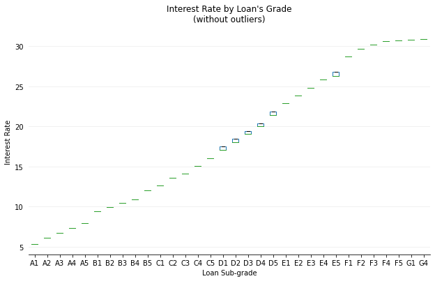

```python
ax = df[['sub_grade', 'interest_rate']].boxplot(figsize=(10,6), by='sub_grade',showfliers=False)
ax.set_xlabel("Loan Sub-grade")
ax.set_ylabel("Interest Rate")
ax.yaxis.grid(True, color='#EEEEEE')
ax.xaxis.grid(False)
ax.spines['top'].set_visible(False)
ax.spines['right'].set_visible(False)
ax.spines['left'].set_visible(False)
ax.yaxis.set_ticks_position('none')
ax.set_axisbelow(True)
plt.title('')
_ = plt.suptitle("Interest Rate by Loan\'s Grade\n(without outliers)")
```

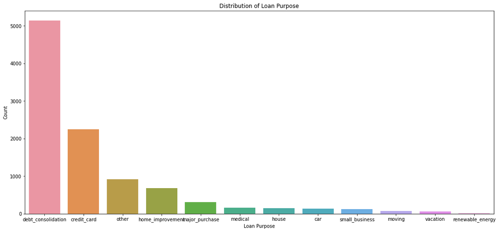

```python
viz_loan_purpose = df['loan_purpose'].value_counts().to_frame().reset_index()
viz_loan_purpose.columns = ['Loan Purpose', 'Count']
plt.subplots(figsize=(18,8))
sns.barplot(y='Count', x='Loan Purpose', data=viz_loan_purpose)
plt.ylabel('Count')
plt.title('Distribution of Loan Purpose')
plt.show()
```

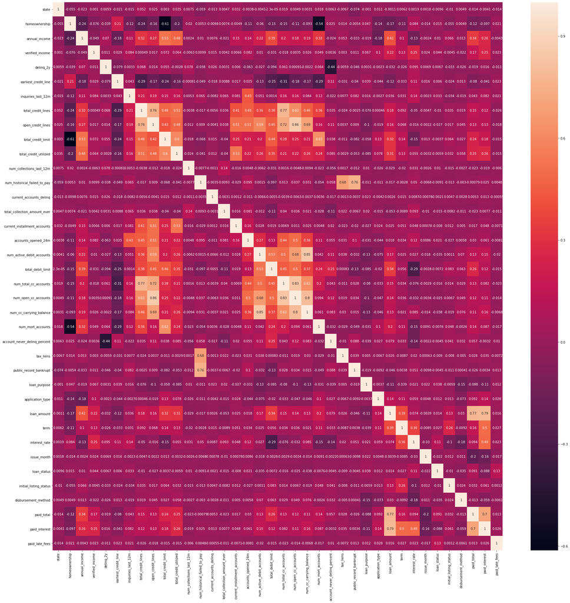

```python
Corr_mat = pd1.corr()
fig, ax = plt.subplots(figsize=(32,32))
sns.heatmap(data=Corr_mat, annot=True)
```

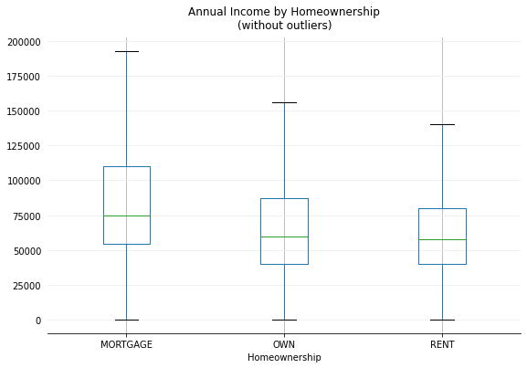

```python
ax = df[['homeownership', 'annual_income']].boxplot(figsize=(9,6), by='homeownership',showfliers=False)
ax.set_xlabel("Homeownership")
ax.yaxis.grid(True, color='#EEEEEE')
ax.spines['top'].set_visible(False)
ax.spines['right'].set_visible(False)
ax.spines['left'].set_visible(False)
ax.yaxis.set_ticks_position('none')
ax.set_axisbelow(True)
plt.title('')
_ = plt.suptitle('Annual Income by Homeownership\n(without outliers)')
```

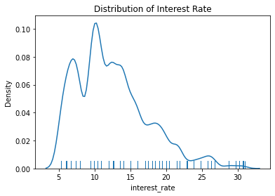

```python
sns.distplot(df["interest_rate"], rug=True,hist=False);
plt.title("Distribution of Interest Rate");
plt.ylabel("Density");
```

# Model

```python
Y = pd2['interest_rate']
```

```python
X = pd2.drop(['interest_rate'], axis=1)
```

```python
from sklearn import preprocessing
from sklearn.preprocessing import StandardScaler
scaler = StandardScaler().fit(X)
st_X = scaler.transform(X)
```

```python
from sklearn.model_selection import train_test_split
x_train, x_test, y_train, y_test = train_test_split(st_X, Y, test_size=0.2)
```

```python
from sklearn.linear_model import LinearRegression
from sklearn.model_selection import train_test_split
from sklearn.metrics import confusion_matrix
from sklearn.metrics import accuracy_score
regressor = LinearRegression()
regressor.fit(x_train, y_train)
```

```
LinearRegression(copy_X=True, fit_intercept=True, n_jobs=None, normalize=False)
```

```python
y_pred = regressor.predict(x_test)
```

```python
error = (1/(2*(x_test.shape[0]))*np.sum(np.abs(y_pred - y_test)))
```

```python
error
```

```
2.602503619661745
```

```python
from sklearn.ensemble import RandomForestRegressor
rf = RandomForestRegressor(n_estimators = 1000, random_state = 42)
rf.fit(x_train, y_train)
predictions = rf.predict(x_test)
errors = abs(predictions - y_test)
print('Mean Absolute Error:', round(np.mean(errors), 2), 'degrees.')
mape = 100 * (errors / y_test)
# Calculate and display accuracy. i tried to calculate overall how much accurate is my model its not literal accuracy measure
accuracy = 100 - np.mean(mape)
```

```
Mean Absolute Error: 2.11 degrees.
```

# Improvements

- If you have more time, talk to a domain expert to learn more about how a loan is valued based on different characteristics (interest rates should be determined in the same way).
- Sepnd more time on studing different features
- Try to get more amount of data so that I can build the model with more accuracy.
- I Will try to implement different Models and figure out which model has less error.
- Also, I can combine multiple model to make one complex model which can fits features more accurately.

# CASE STUDY 2

```python
df = pd.read_csv('C:/Users/Bhargaw/Downloads/stout/casestudy.csv')
```

```python
df
```

|  | Unnamed: 0 | customer_email | net_revenue | year |
| --- | --- | --- | --- | --- |
| 0 | 0 | nhknapwsbx@gmail.com | 249.92 | 2015 |
| 1 | 1 | joiuzbvcpn@gmail.com | 87.61 | 2015 |
| 2 | 2 | ukkjctepxt@gmail.com | 168.38 | 2015 |
| 3 | 3 | gykatilzrt@gmail.com | 62.40 | 2015 |
| 4 | 4 | mmsgsrtxah@gmail.com | 43.08 | 2015 |
| 5 | 5 | mobvusnzfr@gmail.com | 39.44 | 2015 |
| 6 | 6 | kxwkqvacsv@gmail.com | 171.46 | 2015 |
| 7 | 7 | iqmnugdcjs@gmail.com | 111.99 | 2015 |
| 8 | 8 | baiikostmd@gmail.com | 170.70 | 2015 |
| 9 | 9 | lfeafnigbu@gmail.com | 54.99 | 2015 |
| 10 | 10 | utycjynusf@gmail.com | 89.05 | 2015 |
| 11 | 11 | dptyjlaniw@gmail.com | 204.39 | 2015 |
| 12 | 12 | ywioceuqnw@gmail.com | 76.70 | 2015 |
| 13 | 13 | hrnaahgrqr@gmail.com | 65.32 | 2015 |
| 14 | 14 | sktswronzp@gmail.com | 102.87 | 2015 |
| 15 | 15 | tqxsjlgjpi@gmail.com | 107.71 | 2015 |
| 16 | 16 | hxshgpdxtr@gmail.com | 180.59 | 2015 |
| 17 | 17 | ifilbfvetw@gmail.com | 215.90 | 2015 |
| 18 | 18 | urqinnnoue@gmail.com | 181.91 | 2015 |
| 19 | 19 | mzqkkusvjz@gmail.com | 38.53 | 2015 |
| 20 | 20 | kdshnrqshe@gmail.com | 245.25 | 2015 |
| 21 | 21 | ehgpdadhkb@gmail.com | 157.16 | 2015 |
| 22 | 22 | hdefrrdccu@gmail.com | 174.05 | 2015 |
| 23 | 23 | ithsayiheg@gmail.com | 43.62 | 2015 |
| 24 | 24 | zvhsssvgor@gmail.com | 21.55 | 2015 |
| 25 | 25 | gkdstuxmfk@gmail.com | 94.02 | 2015 |
| 26 | 26 | jjafctqaqe@gmail.com | 32.09 | 2015 |
| 27 | 27 | xiwenewrdq@gmail.com | 222.78 | 2015 |
| 28 | 28 | gipqsrvngd@gmail.com | 122.71 | 2015 |
| 29 | 29 | iqdogiwbsn@gmail.com | 243.29 | 2015 |
| ... | ... | ... | ... | ... |
| 685897 | 685897 | iywyglkteo@gmail.com | 32.75 | 2017 |
| 685898 | 685898 | lfwemuyqda@gmail.com | 100.12 | 2017 |
| 685899 | 685899 | hanlutgsgg@gmail.com | 48.23 | 2017 |
| 685900 | 685900 | lpwknthhhv@gmail.com | 73.46 | 2017 |
| 685901 | 685901 | pkrqlgkbvq@gmail.com | 32.29 | 2017 |
| 685902 | 685902 | lyhyaxwwyi@gmail.com | 189.14 | 2017 |
| 685903 | 685903 | sraqcddfhm@gmail.com | 185.40 | 2017 |
| 685904 | 685904 | qbaefiegzy@gmail.com | 140.45 | 2017 |
| 685905 | 685905 | qxvgljgoaz@gmail.com | 98.30 | 2017 |
| 685906 | 685906 | xrocvfcxkc@gmail.com | 76.89 | 2017 |
| 685907 | 685907 | cwchfeemrt@gmail.com | 196.81 | 2017 |
| 685908 | 685908 | xlushgnklq@gmail.com | 210.08 | 2017 |
| 685909 | 685909 | uceftefbue@gmail.com | 186.64 | 2017 |
| 685910 | 685910 | welqxspxrr@gmail.com | 65.69 | 2017 |
| 685911 | 685911 | hfcneizrfe@gmail.com | 156.41 | 2017 |
| 685912 | 685912 | jtpqyjnygw@gmail.com | 236.81 | 2017 |
| 685913 | 685913 | ttvxxjocpm@gmail.com | 50.00 | 2017 |
| 685914 | 685914 | apqzyumkxw@gmail.com | 183.37 | 2017 |
| 685915 | 685915 | brtgngdaqn@gmail.com | 138.45 | 2017 |
| 685916 | 685916 | byegtrcmou@gmail.com | 74.52 | 2017 |
| 685917 | 685917 | adcqmnolkw@gmail.com | 200.76 | 2017 |
| 685918 | 685918 | vdftaqwvss@gmail.com | 141.41 | 2017 |
| 685919 | 685919 | cmzjlgghyf@gmail.com | 104.11 | 2017 |
| 685920 | 685920 | dewkfxtfci@gmail.com | 52.92 | 2017 |
| 685921 | 685921 | uxhfpljojw@gmail.com | 106.88 | 2017 |
| 685922 | 685922 | qzqttwiftu@gmail.com | 184.58 | 2017 |
| 685923 | 685923 | pjodiifjop@gmail.com | 133.03 | 2017 |
| 685924 | 685924 | appaplmgko@gmail.com | 200.98 | 2017 |
| 685925 | 685925 | wvkpmwsgck@gmail.com | 235.35 | 2017 |
| 685926 | 685926 | aregboumbw@gmail.com | 208.43 | 2017 |

685927 rows × 4 columns

```python
current_year = list(df['year'].unique())
current_year = max(current_year)
current_year
df_2017 = df[df['year'] == current_year]
df_2016 = df[df['year'] == 2016]
df_2017
```

|  | Unnamed: 0 | customer_email | net_revenue | year |
| --- | --- | --- | --- | --- |
| 435940 | 435940 | mwrossuukz@gmail.com | 96.61 | 2017 |
| 435941 | 435941 | qvjfterwnk@gmail.com | 176.00 | 2017 |
| 435942 | 435942 | vlyigtgfzs@gmail.com | 73.47 | 2017 |
| 435943 | 435943 | yfirychuhk@gmail.com | 138.17 | 2017 |
| 435944 | 435944 | fdkiioqtli@gmail.com | 156.87 | 2017 |
| 435945 | 435945 | vpsfdhgrfo@gmail.com | 214.53 | 2017 |
| 435946 | 435946 | dkbsemibna@gmail.com | 95.54 | 2017 |
| 435947 | 435947 | yixtbjnxce@gmail.com | 133.86 | 2017 |
| 435948 | 435948 | baiikostmd@gmail.com | 72.21 | 2017 |
| 435949 | 435949 | pnnenkxlpj@gmail.com | 35.92 | 2017 |
| 435950 | 435950 | qkjragcrsd@gmail.com | 11.31 | 2017 |
| 435951 | 435951 | sqashwoqai@gmail.com | 3.89 | 2017 |
| 435952 | 435952 | thcyofilac@gmail.com | 34.50 | 2017 |
| 435953 | 435953 | gwqjyelgct@gmail.com | 164.10 | 2017 |
| 435954 | 435954 | sktswronzp@gmail.com | 155.42 | 2017 |
| 435955 | 435955 | ylqsflvinx@gmail.com | 106.05 | 2017 |
| 435956 | 435956 | hxshgpdxtr@gmail.com | 178.10 | 2017 |
| 435957 | 435957 | ibcpxxfdru@gmail.com | 91.19 | 2017 |
| 435958 | 435958 | actvovcfwt@gmail.com | 192.21 | 2017 |
| 435959 | 435959 | wacguvfcpu@gmail.com | 1.51 | 2017 |
| 435960 | 435960 | hyorysgxcy@gmail.com | 93.21 | 2017 |
| 435961 | 435961 | oaljnsfofg@gmail.com | 221.36 | 2017 |
| 435962 | 435962 | brlldbihsl@gmail.com | 164.90 | 2017 |
| 435963 | 435963 | irlqcsvlvl@gmail.com | 144.64 | 2017 |
| 435964 | 435964 | zvhsssvgor@gmail.com | 148.54 | 2017 |
| 435965 | 435965 | vmjxhxouyr@gmail.com | 106.42 | 2017 |
| 435966 | 435966 | wylyxexpnm@gmail.com | 153.18 | 2017 |
| 435967 | 435967 | hqovqeseuw@gmail.com | 103.81 | 2017 |
| 435968 | 435968 | gipqsrvngd@gmail.com | 172.90 | 2017 |
| 435969 | 435969 | dsbbvsfmad@gmail.com | 244.20 | 2017 |
| ... | ... | ... | ... | ... |
| 685897 | 685897 | iywyglkteo@gmail.com | 32.75 | 2017 |
| 685898 | 685898 | lfwemuyqda@gmail.com | 100.12 | 2017 |
| 685899 | 685899 | hanlutgsgg@gmail.com | 48.23 | 2017 |
| 685900 | 685900 | lpwknthhhv@gmail.com | 73.46 | 2017 |
| 685901 | 685901 | pkrqlgkbvq@gmail.com | 32.29 | 2017 |
| 685902 | 685902 | lyhyaxwwyi@gmail.com | 189.14 | 2017 |
| 685903 | 685903 | sraqcddfhm@gmail.com | 185.40 | 2017 |
| 685904 | 685904 | qbaefiegzy@gmail.com | 140.45 | 2017 |
| 685905 | 685905 | qxvgljgoaz@gmail.com | 98.30 | 2017 |
| 685906 | 685906 | xrocvfcxkc@gmail.com | 76.89 | 2017 |
| 685907 | 685907 | cwchfeemrt@gmail.com | 196.81 | 2017 |
| 685908 | 685908 | xlushgnklq@gmail.com | 210.08 | 2017 |
| 685909 | 685909 | uceftefbue@gmail.com | 186.64 | 2017 |
| 685910 | 685910 | welqxspxrr@gmail.com | 65.69 | 2017 |
| 685911 | 685911 | hfcneizrfe@gmail.com | 156.41 | 2017 |
| 685912 | 685912 | jtpqyjnygw@gmail.com | 236.81 | 2017 |
| 685913 | 685913 | ttvxxjocpm@gmail.com | 50.00 | 2017 |
| 685914 | 685914 | apqzyumkxw@gmail.com | 183.37 | 2017 |
| 685915 | 685915 | brtgngdaqn@gmail.com | 138.45 | 2017 |
| 685916 | 685916 | byegtrcmou@gmail.com | 74.52 | 2017 |
| 685917 | 685917 | adcqmnolkw@gmail.com | 200.76 | 2017 |
| 685918 | 685918 | vdftaqwvss@gmail.com | 141.41 | 2017 |
| 685919 | 685919 | cmzjlgghyf@gmail.com | 104.11 | 2017 |
| 685920 | 685920 | dewkfxtfci@gmail.com | 52.92 | 2017 |
| 685921 | 685921 | uxhfpljojw@gmail.com | 106.88 | 2017 |
| 685922 | 685922 | qzqttwiftu@gmail.com | 184.58 | 2017 |
| 685923 | 685923 | pjodiifjop@gmail.com | 133.03 | 2017 |
| 685924 | 685924 | appaplmgko@gmail.com | 200.98 | 2017 |
| 685925 | 685925 | wvkpmwsgck@gmail.com | 235.35 | 2017 |
| 685926 | 685926 | aregboumbw@gmail.com | 208.43 | 2017 |

249987 rows × 4 columns

```python
# Total revenue for the current year
total_rev_2017 = df_2017['net_revenue'].sum()
total_rev_2017
```

```
31417495.030000016
```

```python
# New Customer Revenue e.g. new customers not present in previous year only
filtered_df = df[(df['year'] < current_year)]

# selecting all the users who were present in previous years and created the list of users email id
emails_ls = list(filtered_df['customer_email'])

# Here selecting only those users who does not present in previous years
inverse_boolean_series = ~(df.customer_email.isin(emails_ls))

filtered_df1 = df[inverse_boolean_series]

New_customer_revenue = filtered_df1.net_revenue.sum()

print("The revenue of new customer is- {}".format(New_customer_revenue))
```

```
The revenue of new customer is- 28676607.64
```

```python
# Existing Customer Growth. To calculate this, use the Revenue of existing customers for current year –(minus) Revenue of existing customers from the previous year
sum_curr = df_2017['net_revenue'].sum()
sum_prior = df_2016['net_revenue'].sum()

cust_growth = sum_curr - sum_prior
print("The Existing custome growth is-", cust_growth)
```

```
The Existing custome growth is- 5686551.440000016
```

```python
# Existing Customer Revenue Current Year
sum_curr = df_2017['net_revenue'].sum()
print("Existing customer revenue current year-",sum_curr)
```

```
Existing customer revenue current year- 31417495.030000016
```

```python
# Existing Customer Revenue Prior Year
sum_prior = df_2016['net_revenue'].sum()
print("Existing customer revenue prior year-",sum_prior)
```

```
Existing customer revenue prior year- 25730943.59
```

```python
# Total Customers Current Year
total_cust_curr = df_2017['customer_email'].count()
print("Total customers current year-",total_cust_curr)
```

```
Total customers current year- 249987
```

```python
# Total Customers Previous Year
total_cust_prev = df_2016['customer_email'].count()
print("Total customers previous year-",total_cust_prev)
```

```
Total customers previous year- 204646
```

```python
filtered_df = df[(df['year'] < current_year)]

# selecting all the users who were present in previous years and created the list of users email id
emails_ls = list(filtered_df['customer_email'])

# Here selecting only those users who does not present in previous years
inverse_boolean_series = ~(df.customer_email.isin(emails_ls))

filtered_df1 = df[inverse_boolean_series]

New_customer_revenue = filtered_df1.net_revenue.sum()

print("The revenue of new customer is- {}".format(New_customer_revenue))
```

[output not shown]

```python
# New Customers
filtered_df = df[(df['year'] < current_year)]

# selecting all the users who were present in previous years and created the list of users email id
emails_ls = list(filtered_df['customer_email'])

# Here selecting only those users who does not present in previous years
inverse_boolean_series = ~(df.customer_email.isin(emails_ls))

filtered_df1 = df[inverse_boolean_series]

print("New customers-")
filtered_df1
```

```
New customers-
```

[output not shown]

228262 rows × 4 columns

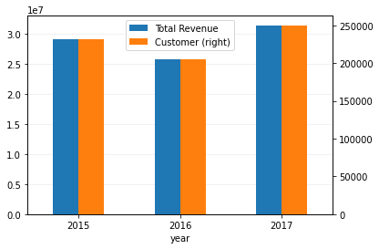

```python
rvn_by_year=df.groupby('year')['net_revenue'].sum()
rvn_by_year.name='Total Revenue'
cstm_by_year=df.groupby('year').size()
cstm_by_year.name='Customer'
rvn_cstm_by_year = pd.concat([rvn_by_year,cstm_by_year], axis=1)
ax=rvn_cstm_by_year.plot.bar(secondary_y= 'Customer', rot= 0)
ax.yaxis.grid(True, color='#EEEEEE')
ax.set_axisbelow(True)
```

```python
import string
letters = dict(zip(string.ascii_lowercase, [0]*26))
emails=df['customer_email'].unique()
for email in emails:
    for letter in email.split('@')[0]:
        if letter==' ':
            continue
        else:
            letters[letter]+=1
print(letters)
```

[output not shown]

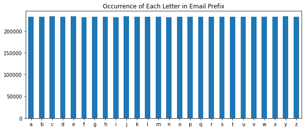

```python
_=pd.Series(letters).plot(kind='bar', rot=0, title='Occurrence of Each Letter in Email Prefix', figsize=(10,4))
```